# Linear Model Evaluation: Model Performance

## Linear Model Evaluation: the big picture

[figure not shown]

**Evaluation: Is our model useful?**

- Does the model satisfy its assumptions?
- Is the model accurate? Does it predict new observations well?

## The data

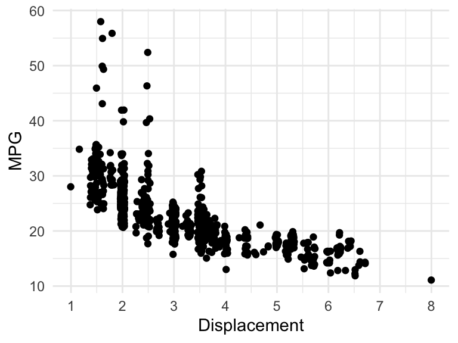

```r
cars_displ <- lm(MPG ~ Displacement,
                 data = cars_train)
tidy(cars_displ)
```

| term | estimate | std.error | statistic | p.value |
| --- | --- | --- | --- | --- |
| (Intercept) | 32.74 | 0.35 | 92.30 | 0 |
| Displacement | -3.11 | 0.10 | -29.71 | 0 |

## A Familiar Statistic: \(R^2\)

\[ R^2 = 1 - \frac{RSS}{SST} = 1 - \frac{\sum(y_i - \hat{y}_i)^2}{\sum(y_i - \bar{y})^2} \]

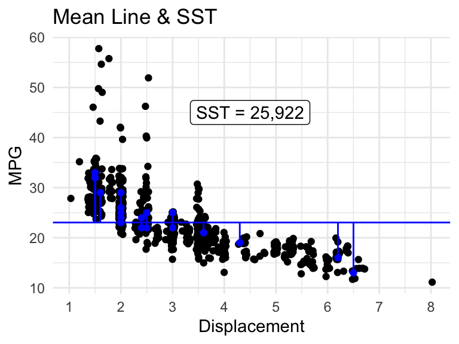

\(R^2\) is the proportion of variation in the response variable explained by the model.

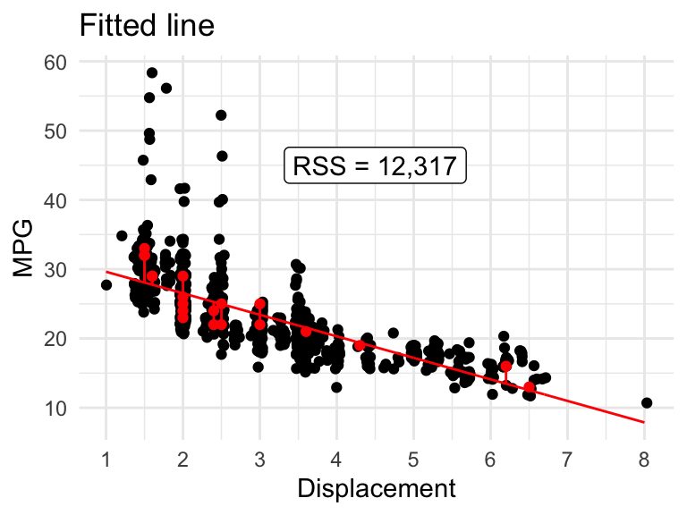

## When \(R^2\) fails

Model with 2 additional “garbage” variables has an \(R^2\) of 0.53, whereas the previous model with only `Displacement` had an \(R^2\) of 0.52.

```r
set.seed(4783) #for reproducibility
mod_garbage <-
cars_train %>%
  mutate(garbage1 = rnorm(n()),
         garbage2 = rnorm(n())) %>%
  lm(MPG ~ Displacement + garbage1 + garbage2,
     data = .)
tidy(mod_garbage)
```

[output not shown]

The code below will compute \(R^2\):

```r
glance(cars_displ) %>% select(r.squared)
glance(mod_garbage) %>% select(r.squared)
```

[output not shown]

## Adj. \(R^2\)

If we have \(n\) observations and \(p\) is the number of explanatory variables in the model,

\[ Adj. R^2 = 1 - \Big[(1 - R^2)\frac{n-1}{n-p-1}\Big] \]

As the number of predictors, \(p\), increases, \(R^2\) increases, which means \(1-R^2\) decreases. But also as \(p\) increases \(\frac{n-1}{n-p-1}\) increases.

## Adj. \(R^2\) example

In the two models we examined, we see that even though \(R^2\) increases, adjusted \(R^2\) decreases when the garbage variables are added to the model.

| model | r.squared | adj.r.squared |
| --- | --- | --- |
| Only Displacement | 0.5248 | 0.5242 |
| Displacement and garbage | 0.5254 | 0.5236 |

## RMSE

The root mean squared error, RMSE, is computed as

\[ RMSE = \sqrt{\frac{1}{n}\sum_{i=1}^n(y_i - \hat{y}_i)^2}, \]

and is the square root of the average sum of the squared residuals. In practice, this quantity tells us approximately the average distance between the actual and predicted values. Or, on average, how far off a prediction will be.

The RMSE for the model that only uses `Displacement` to model `MPG` is computed below.

```r
augment(cars_displ) %>%
  summarize(rmse = sqrt(mean(.resid^2)))
```

```
## # A tibble: 1 x 1
##    rmse
##   <dbl>
## 1  3.92
```

## Overfitting

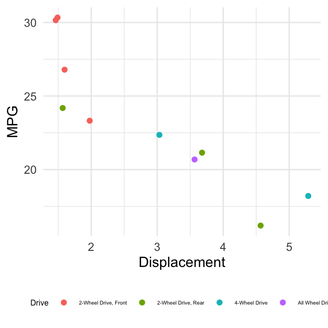

| term | estimate | p.value |
| --- | --- | --- |
| (Intercept) | 51.7 | 0 |
| Displacement | -10.0 | 0 |
| Drive2-Wheel Drive, Rear | -32.0 | 0 |
| Drive4-Wheel Drive | -23.0 | 0 |
| DriveAll Wheel Drive | 3.5 | 0 |
| Cylinders | 12.8 | 0 |
| `Recommended Fuel`Premium Unleaded Required | 14.3 | 0 |
| `Recommended Fuel`Regular Unleaded Recommended | -14.8 | 0 |
| Gears | -7.5 | 0 |

Adjusted \(R^2=\) 1, RMSE= 0.